# Part I - Ford GoBike System Data

## Introduction

> This data set includes information about individual rides made in a bike-sharing system covering the greater San Francisco Bay area.

## Preliminary Wrangling

```python
# import all packages and set plots to be embedded inline
import numpy as np
import pandas as pd
import matplotlib.pyplot as plt
import seaborn as sb

%matplotlib inline
```

```python
#loading the dataset
df = pd.read_csv('201902-fordgobike-tripdata.csv')
df.head()
```

|  | duration_sec | start_time | end_time | start_station_id | start_station_name | start_station_latitude | start_station_longitude | end_station_id | end_station_name | end_station_latitude | end_station_longitude | bike_id | user_type | member_birth_year | member_gender | bike_share_for_all_trip |
| --- | --- | --- | --- | --- | --- | --- | --- | --- | --- | --- | --- | --- | --- | --- | --- | --- |
| 0 | 52185 | 2019-02-28 17:32:10.1450 | 2019-03-01 08:01:55.9750 | 21.0 | Montgomery St BART Station (Market St at 2nd St) | 37.789625 | -122.400811 | 13.0 | Commercial St at Montgomery St | 37.794231 | -122.402923 | 4902 | Customer | 1984.0 | Male | No |
| 1 | 42521 | 2019-02-28 18:53:21.7890 | 2019-03-01 06:42:03.0560 | 23.0 | The Embarcadero at Steuart St | 37.791464 | -122.391034 | 81.0 | Berry St at 4th St | 37.775880 | -122.393170 | 2535 | Customer | NaN | NaN | No |
| 2 | 61854 | 2019-02-28 12:13:13.2180 | 2019-03-01 05:24:08.1460 | 86.0 | Market St at Dolores St | 37.769305 | -122.426826 | 3.0 | Powell St BART Station (Market St at 4th St) | 37.786375 | -122.404904 | 5905 | Customer | 1972.0 | Male | No |
| 3 | 36490 | 2019-02-28 17:54:26.0100 | 2019-03-01 04:02:36.8420 | 375.0 | Grove St at Masonic Ave | 37.774836 | -122.446546 | 70.0 | Central Ave at Fell St | 37.773311 | -122.444293 | 6638 | Subscriber | 1989.0 | Other | No |
| 4 | 1585 | 2019-02-28 23:54:18.5490 | 2019-03-01 00:20:44.0740 | 7.0 | Frank H Ogawa Plaza | 37.804562 | -122.271738 | 222.0 | 10th Ave at E 15th St | 37.792714 | -122.248780 | 4898 | Subscriber | 1974.0 | Male | Yes |

```python
df.shape
```

```
(183412, 16)
```

```python
df.info()
```

```
<class 'pandas.core.frame.DataFrame'>
RangeIndex: 183412 entries, 0 to 183411
Data columns (total 16 columns):
 #   Column                   Non-Null Count   Dtype
---  ------                   --------------   -----
 0   duration_sec             183412 non-null  int64
 1   start_time               183412 non-null  object
 2   end_time                 183412 non-null  object
 3   start_station_id         183215 non-null  float64
 4   start_station_name       183215 non-null  object
 5   start_station_latitude   183412 non-null  float64
 6   start_station_longitude  183412 non-null  float64
 7   end_station_id           183215 non-null  float64
 8   end_station_name         183215 non-null  object
 9   end_station_latitude     183412 non-null  float64
 10  end_station_longitude    183412 non-null  float64
 11  bike_id                  183412 non-null  int64
 12  user_type                183412 non-null  object
 13  member_birth_year        175147 non-null  float64
 14  member_gender            175147 non-null  object
 15  bike_share_for_all_trip  183412 non-null  object
dtypes: float64(7), int64(2), object(7)
memory usage: 22.4+ MB
```

```python
df.duplicated().sum()
```

```
0
```

```python
df.dtypes
```

```
duration_sec                 int64
start_time                  object
end_time                    object
start_station_id           float64
start_station_name          object
start_station_latitude     float64
start_station_longitude    float64
end_station_id             float64
end_station_name            object
end_station_latitude       float64
end_station_longitude      float64
bike_id                      int64
user_type                   object
member_birth_year          float64
member_gender               object
bike_share_for_all_trip     object
dtype: object
```

```python
df.isnull().sum()
```

```
duration_sec                  0
start_time                    0
end_time                      0
start_station_id            197
start_station_name          197
start_station_latitude        0
start_station_longitude       0
end_station_id              197
end_station_name            197
end_station_latitude          0
end_station_longitude         0
bike_id                       0
user_type                     0
member_birth_year          8265
member_gender              8265
bike_share_for_all_trip       0
dtype: int64
```

### What is the structure of your dataset?

> The dataset has been stored in a pandas dataframe which has 183412 records and 16 features.

### What is/are the main feature(s) of interest in your dataset?

> My main feature of interest is the trip duration and how other features affects it.

### What features in the dataset do you think will help support your investigation into your feature(s) of interest?

> 1. User type
> 2. User age
> 3. Start time
> 4. End time
> 5. Start Station

```python
# Dropping all the records that have missing values in any of the features

df.dropna(inplace=True)
```

```python
df.shape
```

```
(174952, 16)
```

```python
# Converting start_time and end_time into a datetime datatype
df['start_time'] = pd.to_datetime(df['start_time'])
df['end_time'] = pd.to_datetime(df['end_time'])

# Converting member_birth_year into an integer datatype
df['member_birth_year'] = df['member_birth_year'].astype('int')

# Converting start_station_id, end_station_id, and bike_id into a string datatype
df['start_station_id'] = df['start_station_id'].astype('str')
df['end_station_id'] = df['end_station_id'].astype('str')
df['bike_id'] = df['bike_id'].astype('str')
```

```python
df.info()
```

```
<class 'pandas.core.frame.DataFrame'>
Int64Index: 174952 entries, 0 to 183411
Data columns (total 16 columns):
 #   Column                   Non-Null Count   Dtype
---  ------                   --------------   -----
 0   duration_sec             174952 non-null  int64
 1   start_time               174952 non-null  datetime64[ns]
 2   end_time                 174952 non-null  datetime64[ns]
 3   start_station_id         174952 non-null  object
 4   start_station_name       174952 non-null  object
 5   start_station_latitude   174952 non-null  float64
 6   start_station_longitude  174952 non-null  float64
 7   end_station_id           174952 non-null  object
 8   end_station_name         174952 non-null  object
 9   end_station_latitude     174952 non-null  float64
 10  end_station_longitude    174952 non-null  float64
 11  bike_id                  174952 non-null  object
 12  user_type                174952 non-null  object
 13  member_birth_year        174952 non-null  int64
 14  member_gender            174952 non-null  object
 15  bike_share_for_all_trip  174952 non-null  object
dtypes: datetime64[ns](2), float64(4), int64(2), object(8)
memory usage: 22.7+ MB
```

```python
# Getting the age from the birth_year
df['member_age'] = 2022 - df['member_birth_year']

# For a less complicated view, I will add a column converting the duration from sec to min
df['duration_min'] = df['duration_sec']/60

df['member_age'].value_counts()
```

```
34     10214
29      9323
33      8967
32      8640
31      8484
       ...
94         1
144        1
92         1
112        1
95         1
Name: member_age, Length: 75, dtype: int64
```

```python
df.head()
```

|  | duration_sec | start_time | end_time | start_station_id | start_station_name | start_station_latitude | start_station_longitude | end_station_id | end_station_name | end_station_latitude | end_station_longitude | bike_id | user_type | member_birth_year | member_gender | bike_share_for_all_trip | member_age | duration_min |
| --- | --- | --- | --- | --- | --- | --- | --- | --- | --- | --- | --- | --- | --- | --- | --- | --- | --- | --- |
| 0 | 52185 | 2019-02-28 17:32:10.145 | 2019-03-01 08:01:55.975 | 21.0 | Montgomery St BART Station (Market St at 2nd St) | 37.789625 | -122.400811 | 13.0 | Commercial St at Montgomery St | 37.794231 | -122.402923 | 4902 | Customer | 1984 | Male | No | 38 | 869.750000 |
| 2 | 61854 | 2019-02-28 12:13:13.218 | 2019-03-01 05:24:08.146 | 86.0 | Market St at Dolores St | 37.769305 | -122.426826 | 3.0 | Powell St BART Station (Market St at 4th St) | 37.786375 | -122.404904 | 5905 | Customer | 1972 | Male | No | 50 | 1030.900000 |
| 3 | 36490 | 2019-02-28 17:54:26.010 | 2019-03-01 04:02:36.842 | 375.0 | Grove St at Masonic Ave | 37.774836 | -122.446546 | 70.0 | Central Ave at Fell St | 37.773311 | -122.444293 | 6638 | Subscriber | 1989 | Other | No | 33 | 608.166667 |
| 4 | 1585 | 2019-02-28 23:54:18.549 | 2019-03-01 00:20:44.074 | 7.0 | Frank H Ogawa Plaza | 37.804562 | -122.271738 | 222.0 | 10th Ave at E 15th St | 37.792714 | -122.248780 | 4898 | Subscriber | 1974 | Male | Yes | 48 | 26.416667 |
| 5 | 1793 | 2019-02-28 23:49:58.632 | 2019-03-01 00:19:51.760 | 93.0 | 4th St at Mission Bay Blvd S | 37.770407 | -122.391198 | 323.0 | Broadway at Kearny | 37.798014 | -122.405950 | 5200 | Subscriber | 1959 | Male | No | 63 | 29.883333 |

## Univariate Exploration

> In this section, I will be investigating distributions of individual variables. If there are unusual points or outliers, it would be cleaned preparing myself look at relationships between variables.

```python
#  looking into the different user_type that we have
df['user_type'].value_counts()
```

```
Subscriber    158386
Customer       16566
Name: user_type, dtype: int64
```

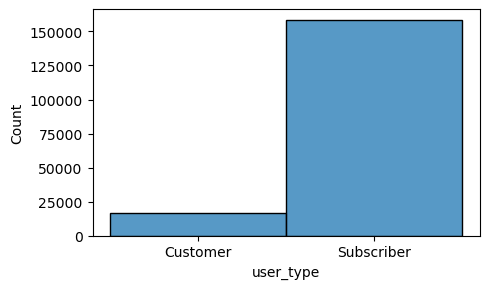

```python
plt.figure(figsize=(5,3), dpi = 100)
sb.histplot(df, x='user_type')
plt.show()
```

From the char above, it is glaring that most of the bike users are subscriber

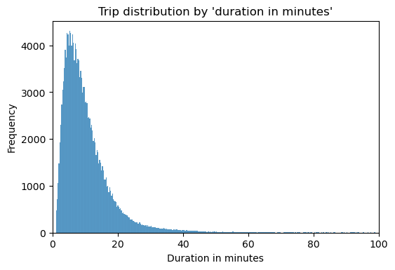

```python
# duration in minutes

plt.figure(figsize = (6, 4), dpi = 100)

sb.histplot(df, x="duration_min")
plt.xlim(0, 100)
plt.title("Trip distribution by 'duration in minutes'")
plt.xlabel('Duration in minutes')
plt.ylabel('Frequency')
plt.show()
```

From the chart above it is seen that most bike riders get a trip with a relatively short period of tike.

```python
# Start_stations with the highest number of occurrence
top_start_stations = df.start_station_name.value_counts()[:10].sort_values(ascending=False)
top_start_stations
```

```
Market St at 10th St                                         3649
San Francisco Caltrain Station 2  (Townsend St at 4th St)    3408
Berry St at 4th St                                           2952
Montgomery St BART Station (Market St at 2nd St)             2711
Powell St BART Station (Market St at 4th St)                 2620
San Francisco Caltrain (Townsend St at 4th St)               2577
San Francisco Ferry Building (Harry Bridges Plaza)           2541
Howard St at Beale St                                        2216
Steuart St at Market St                                      2191
Powell St BART Station (Market St at 5th St)                 2144
Name: start_station_name, dtype: int64
```

```python
# Creats a subplot function that plots a variable against an integer
def subPlot(x, y, xlab, ylab, title):

    plt.figure(figsize=(15,10))
    plt.subplot(2,1,2)
    plt.bar(x.index , y.values)
    plt.ylabel(ylab , size= 12)
    plt.xlabel(xlab , size= 12)
    plt.title(title)
    plt.xticks(rotation = 80)
```

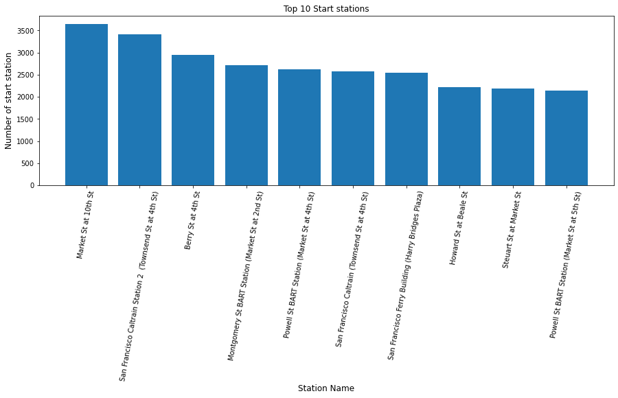

```python
#Subplot is called to plot the top 10 start stations.
subPlot(top_start_stations, top_start_stations, 'Station Name', 'Number of start station', 'Top 10 Start stations')
```

```python
# end_stations with the highest number of occurrence
top_end_stations = df.end_station_name.value_counts()[:10].sort_values(ascending=False)
top_end_stations
```

```
San Francisco Caltrain Station 2  (Townsend St at 4th St)    4624
Market St at 10th St                                         3709
Montgomery St BART Station (Market St at 2nd St)             3461
San Francisco Ferry Building (Harry Bridges Plaza)           3151
San Francisco Caltrain (Townsend St at 4th St)               2870
Powell St BART Station (Market St at 4th St)                 2854
Berry St at 4th St                                           2782
The Embarcadero at Sansome St                                2341
Steuart St at Market St                                      2264
Powell St BART Station (Market St at 5th St)                 2153
Name: end_station_name, dtype: int64
```

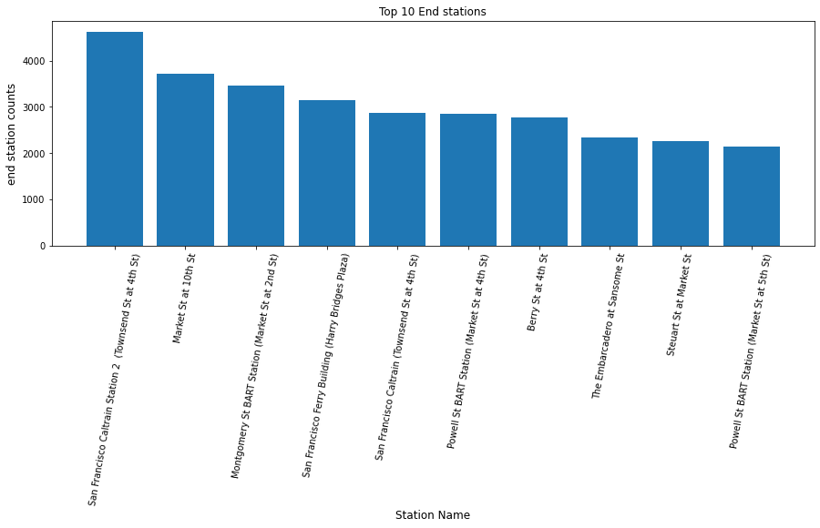

```python
subPlot(top_end_stations, top_end_stations, 'Station Name', 'end station counts', 'Top 10 End stations')
```

From the two charts above, San Francisco Caltrain Station 2 (Townsend St at 4th St) and Market St at 10th St happens to be the most popular stations has they ranked high from the analysis both from the start stations and the end stations.

[figure not shown]

```python
#Age Count using a liner graph
plt.figure(figsize=[20, 10])
sb.lineplot(df['member_age'].unique(), df['member_age'].value_counts())
plt.xlabel('Age', size= 17)
plt.ylabel('Counts', size= 17)
plt.title('Age Count Graph', size= 17)
plt.show();
```

```python
gender = df.member_gender.value_counts()
gender_percentages = (gender/gender.sum())*100
print(gender)
print('\nGender percentage')
print(gender_percentages)
```

```
Male      130500
Female     40805
Other       3647
Name: member_gender, dtype: int64

Gender percentage
Male      74.591888
Female    23.323540
Other      2.084572
Name: member_gender, dtype: float64
```

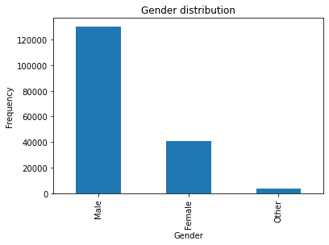

```python
plt.xlabel('Gender')
plt.ylabel('Frequency')
plt.title('Gender distribution')
gender.plot(kind='bar')
```

we see that male has the highest freuency with 74.6% and female with 23.3%

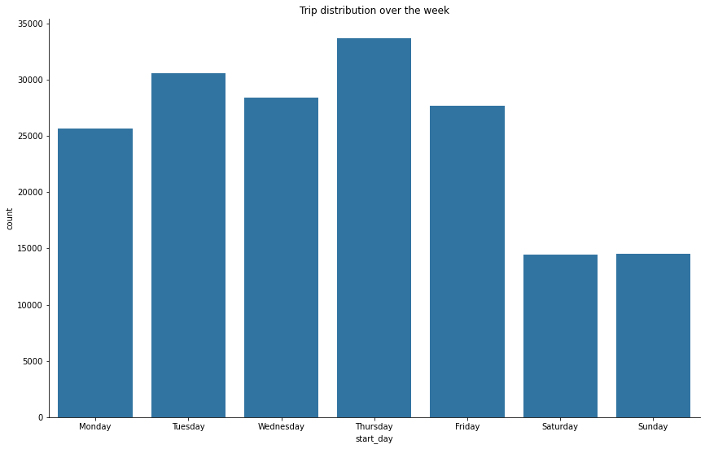

```python
df['start_date'] = df.start_time.dt.strftime('%Y-%m-%d')
df['start_hour'] = df.start_time.dt.strftime('%H')
df['start_day'] = df.start_time.dt.strftime('%A')
df['start_month'] = df.start_time.dt.strftime('%B')
order_of_days = df['start_day'].value_counts()
# days_index = order_of_days.index
day_order = ['Monday','Tuesday','Wednesday','Thursday','Friday','Saturday','Sunday']
base_color = sb.color_palette()[0]

freq_days = sb.catplot(data=df, x='start_day', kind='count', color=base_color, order=day_order)
plt.title('Trip distribution over the week')
freq_days.fig.set_size_inches(14,8);
```

Demand for trips is at its highest level on Thursday. Saturdays and Sundays happens to have the lowest number of demands probably because they are weekend.

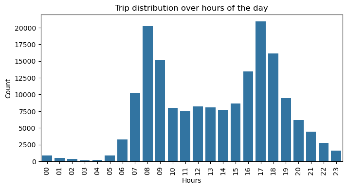

```python
# trip distribution over day hours
plt.figure(figsize = (8,4), dpi = 100)

hour = ['00', '01', '02', '03', '04', '05', '06', '07', '08', '09', '10', '11', '12', '13', '14', '15', '16', '17', '18', '19', '20', '21', '22', '23']
hour_category = pd.api.types.CategoricalDtype(ordered=True, categories=hour)
df['start_hour'] = df['start_hour'].astype(hour_category)


sb.countplot(data = df, x = "start_hour", color = base_color)
plt.title("Trip distribution over hours of the day")
plt.xlabel('Hours')
plt.ylabel('Count')
plt.xticks(rotation = 90)
plt.show()
```

From the chart above, we see that the hours of 8-9am and 5-6pm have the highest number of trips, which may implies the period at which workers, student and artisan goes to work/school and come back home.

### Discuss the distribution(s) of your variable(s) of interest. Were there any unusual points? Did you need to perform any transformations?

1. The majority of riders are subscribers between the ages of 20 and 60.
2. Trips are more frequent during the weekdays with more rides during opening and closing working hours than on weekends implying that the majority of bike users are working-class, students and residents who use bikes to commute to work/school.

### Of the features you investigated, were there any unusual distributions? Did you perform any operations on the data to tidy, adjust, or change the form of the data? If so, why did you do this?

1. Member's age was calculated by subtracting the birthyear from the current year. This was done to provide a more comprehensive picture of the analysis.
2. Trip duration was converted from seconds to minutes for a less complicated view.

## Bivariate Exploration

> In this section, I will investigate the relationships between pairs of variables in my data. [member_age, gender, user_type, days, trip duration and stations]

To start with, I will look at the relationship between the member age and trip duration

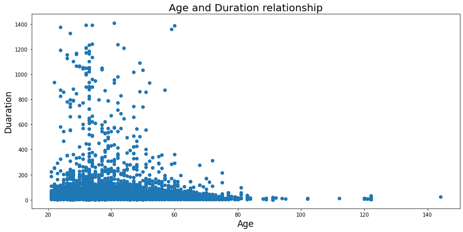

```python
plt.figure(figsize=[15,7])
plt.scatter((df['member_age']), df['duration_min'])
plt.title('Age and Duration relationship', size='20')
plt.xlabel('Age', size='17')
plt.ylabel('Duaration', size='17')
plt.show()
```

from the above chart, the following is observed:

1. Riders within the ages of 20 and 50 tends to travel long distance
2. Most of durations are covered by riders below age 80

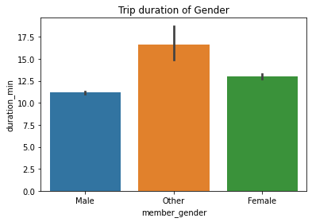

```python
# Plotting the gender of the users to the trip duration (mins)
sb.barplot(data=df, x='member_gender', y='duration_min')
plt.title('Trip duration of Gender');
```

```python
df.groupby('member_gender').duration_min.value_counts().sort_values(ascending= True)[:10]
```

```
member_gender  duration_min
Other          1375.200000     1
Female         132.633333      1
               133.383333      1
               133.783333      1
               134.800000      1
               136.083333      1
               136.233333      1
               136.383333      1
               136.650000      1
               136.900000      1
Name: duration_min, dtype: int64
```

The barplot and the figure above shows that other gender travels longer distance that the male and female gender.

#### Relationship between gender and user_type

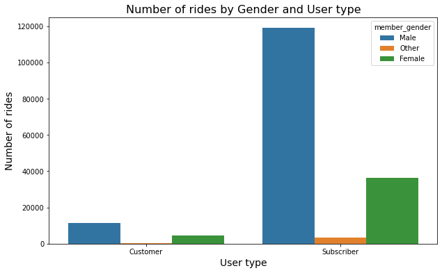

```python
plt.figure(figsize=(10,6))

sb.countplot(data=df, x='user_type', hue='member_gender')
plt.xlabel('User type', size=14)
plt.ylabel('Number of rides', size=14)
plt.title("Number of rides by Gender and User type", size=16);
```

```python
#Checking through figures
df.groupby('user_type').member_gender.value_counts()
```

```
user_type   member_gender
Customer    Male              11493
            Female             4623
            Other               450
Subscriber  Male             119007
            Female            36182
            Other              3197
Name: member_gender, dtype: int64
```

#### Trip distribution over weekdays

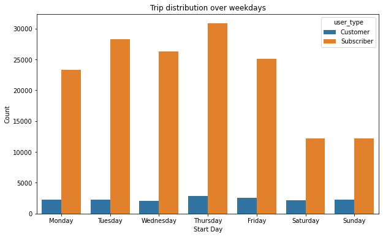

```python
plt.figure(figsize = (10,6))

sb.countplot(data=df, x='start_day', hue='user_type', order=day_order)
plt.xlabel('Start Day')
plt.ylabel('Count')
plt.title("Trip distribution over weekdays")

plt.show()
```

Subscribers appear to use the system on a daily basis probably due to work and study. As a result, the number of their rides is lowest on weekends in contrast to the customers user type

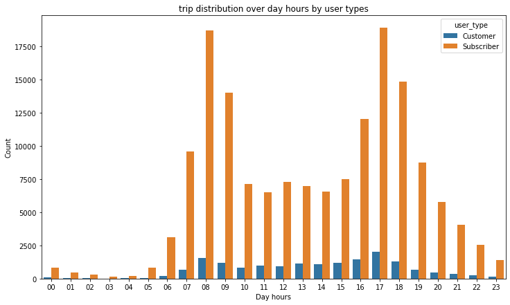

```python
plt.figure(figsize = (12,7))

sb.countplot(data = df, x = "start_hour", hue='user_type')
plt.title("trip distribution over day hours by user types")
plt.xlabel('Day hours')
plt.ylabel('Count')

plt.show()
```

The graph shows that peak hours for both user types are between 7 and 9 a.m. and 4 and 6 p.m. This might be connected to when employees and students arrive at and depart work and school.

### Did you observe any interesting relationships between the other features (not the main feature(s) of interest)?

> The interesting relationships between other features for me is the fact that female gender travels longer distance than male gender. I never expected that.

## Multivariate Exploration

#### user_type, gender and duration

```python
#Time spent on average by gender within each user type
df.groupby(['user_type', 'member_gender'])['duration_min'].mean()
```

```
user_type   member_gender
Customer    Female           23.735468
            Male             20.893225
            Other            26.705000
Subscriber  Female           11.607134
            Male             10.271101
            Other            15.202909
Name: duration_min, dtype: float64
```

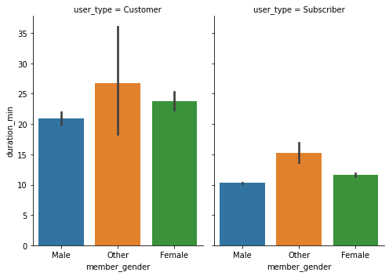

```python
#using catplot to show the relationship between trip duration, user type and gender
sb.catplot(x = "member_gender", y = "duration_min", col = "user_type", data = df, kind = "bar", aspect=.7);
```

We can observe that customers have a higher mean trip than subscribers. Also,the 'other' gender averagely spend longer time on trips than any other gender;

#### Duration, user type, and gender

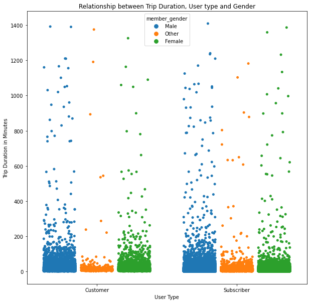

```python
# Visuallizing the relation between trip duration with user type and gender using strip plot
plt.figure(figsize =[10, 10])
sb.stripplot(data =df, x="user_type", y="duration_min", hue = 'member_gender', jitter= 0.34, dodge =True)
plt.title("Relationship between Trip Duration, User type and Gender")
plt.xlabel("User Type")
plt.ylabel("Trip Duration in Minutes");
```

#### Duration, usertype and days of the week

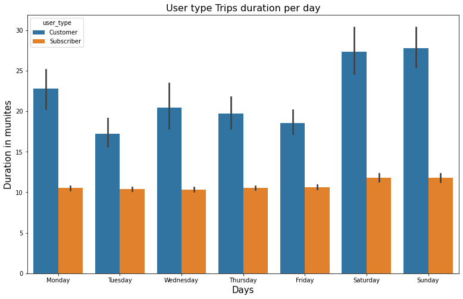

```python
# Barplot to show rel btw trip duration, usertype and days
plt.figure(figsize=(13, 8))
sb.barplot(data=df, x='start_day', hue='user_type', y = 'duration_min', order=day_order)
plt.title("User type Trips duration per day", fontsize=16);
plt.xlabel('Days', size=15)
plt.ylabel('Duration in munites', size=15)
```

According to the above graph, both user types spend more time on the road on weekends than on weekdays, however costumers spend more time on the road than subscribers

### Talk about some of the relationships you observed in this part of the investigation. Were there features that strengthened each other in terms of looking at your feature(s) of interest?

1. Customers have longer trips than subscribers.
2. Both usertypes travels relatively long distance on weekends than week days.

### Were there any interesting or surprising interactions between features?

> No

## Conclusion

This analysis establishes the fact that those who use bikes as a mode of transportation do so more on weekdays than on weekends, with peak hours being when they ride to and from work/school.

```python
df.to_csv('cleaned_go_ford_bike.csv', index=False)
```